# Drink and Thrive? German Economics of Binge-Drinking

Torben and Alex

16 December 2016

## Introduction

People like to drink alcohol for pleasure – and there is nothing wrong with that. But if you drink alcohol in high amounts, this does not only endanger your health but can also lead to violent behaviour, as many scientific studies have shown.

Consuming high amounts of alcohol is predominantly a problem for younger people, as the following diagram makes clear. It shows the number of people, split into age groups, who got hospitalized because they were drunk:

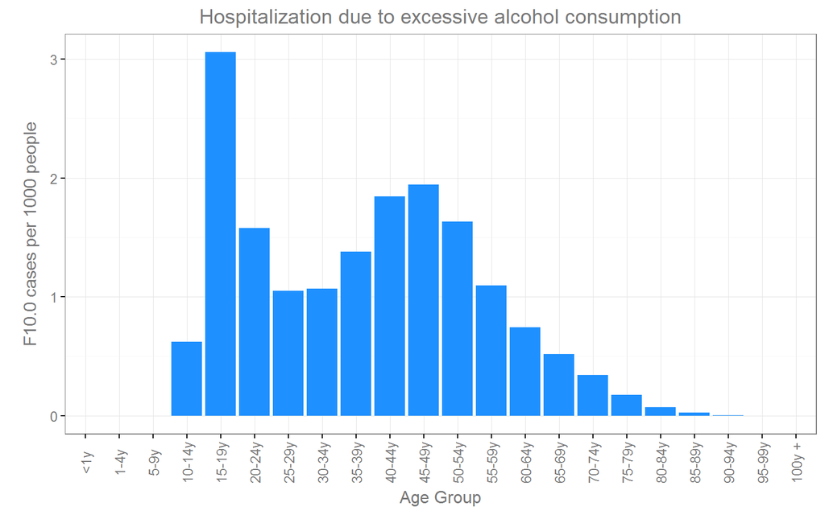

But drinking alcohol does not only have short-term implications like being drunk and hurting yourself or somebody else. Drinking alcohol regularly and in high amounts for example also hurts your liver. Such consequences can only be seen in the long term, as the following graph illustrates. It shows the number and age of people who got hospitalized with alcohol-related liver problems:

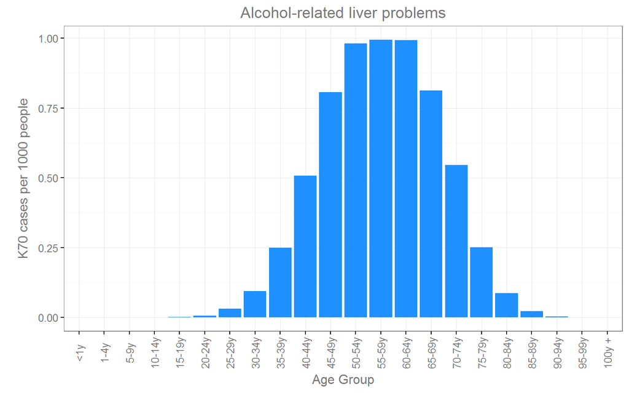

## Binge drinking – an increasing problem

While drinking has been part of the German way of life for centuries, excessive drinking has been a more recent phenomena: Since 2000 there has been a dramatic increase. The following maps compare the relative numbers of excessive alcohol consumption in the years 2000 and 2014:

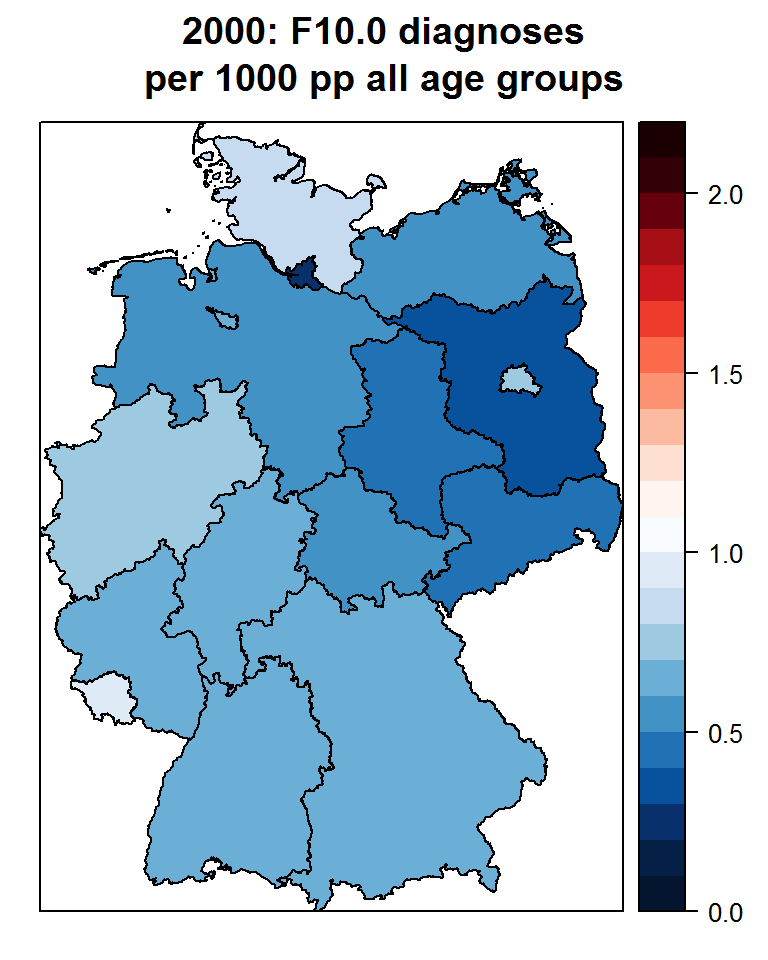

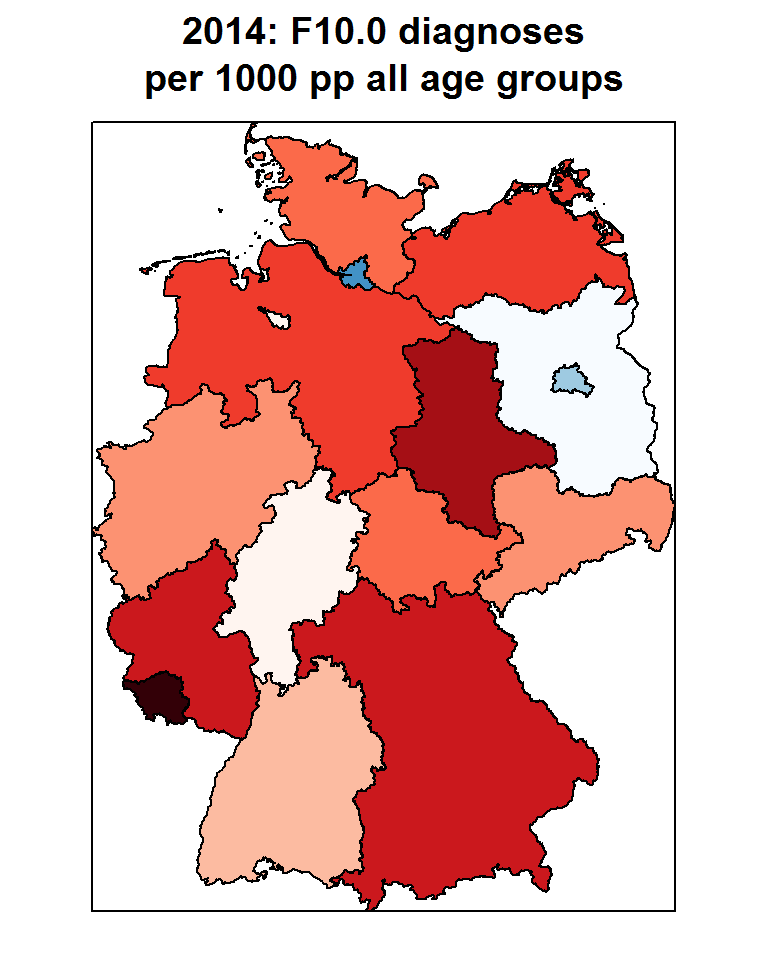

## Policy Response

Politician in Baden Wuerttemberg reacted to the challenge and introduced a night sales ban on alcoholic beverages in 2010. They wanted in particular reduce binge-drinking amoung young people. But has it worked? The following graph gives an overview of all German states from 2000 to 2014. Baden-Wuerttemberg is marked in red, and the three German city states (Bremen, Berlin, and Hamburg) are marked in blue, as their levels of alcohol intoxications have remained comparably low over time.

[interactive chart not shown]

## Has the ban worked?

The question for our research was: Has the ban worked? In our paper, which is accessible in extenso [here](https://github.com/torbatschow/CSSR_Project/blob/master/CSSR-Project.pdf), we were able to show that for young people it has, indeed. We conducted a statistical simulation which showed that the current numbers of alcohol intoxications are around 20 percent lower than they would be if the ban had not been introduced:

[interactive chart not shown]

#### This ain’t magic. It’s reproducible research made possible by [Christopher Gandrud and the Hertie School](https://github.com/HertieDataScience).